Install the neccessary libaries. leaps is used to install the regsubset functions to perform a subset regression analysis.

```r
library(car)
library(leaps)
```

We then read the csv file which is from this link:https://www.kaggle.com/ronitf/heart-disease-uci.

```r
df = read.csv('heart.csv')
View(df)
```

Initialise the independent variables.

```r
age = as.numeric(df$age)
sex = as.numeric(df$sex)
cp = as.numeric(df$cp)
trtbps = as.numeric(df$trtbps)
chol = as.numeric(df$chol)
fbs = as.numeric(df$fbs)
restecg = as.numeric(df$restecg)
exng = as.numeric(df$exng)
oldpeak = as.numeric(df$oldpeak)
slp = as.numeric(df$slp)
caa = as.numeric(df$caa)
thall = as.numeric(df$thall)
output = as.numeric(df$output)
```

Initialise the dependent variable.

We transform the dependent variable to make the variable normally distributed.

This is to satisfy the assumptions made regarding linear regression.

```r
thalachh = as.numeric(df$thalachh)
hist(thalachh)
thalachh = (as.numeric(df$thalachh))^(1.6031)
hist(thalachh)
```

[output not shown]

We can see the summary of the regression model.

These are the main points that could be derived.

The Multiple R squared is 0.3986.

The Adjusted R squared is 0.3737.

The overall regression is significant.

The sample standard deviation is 580.4.

The intercept,age,trtbps,exng,slp and output are statistically significant. The rest of the variables are not.

```r
model = lm(thalachh~age+sex+trtbps+chol+fbs+restecg+exng+oldpeak+slp+caa+thall+output)
summary(model)
```

```
Call:
lm(formula = thalachh ~ age + sex + trtbps + chol + fbs + restecg +
    exng + oldpeak + slp + caa + thall + output)

Residuals:
     Min       1Q   Median       3Q      Max
-1728.63  -366.74    50.68   381.81  1581.34

Coefficients:
             Estimate Std. Error t value Pr(>|t|)
(Intercept) 3227.1877   393.7928   8.195 8.12e-15 ***
age          -27.9094     4.1187  -6.776 6.87e-11 ***
sex           62.4512    79.1162   0.789 0.430546
trtbps         4.5749     2.0441   2.238 0.025975 *
chol           1.1334     0.6881   1.647 0.100640
fbs           73.6048    97.1821   0.757 0.449431
restecg      -40.0538    65.5451  -0.611 0.541620
exng        -351.2674    80.3277  -4.373 1.71e-05 ***
oldpeak      -29.7615    37.9124  -0.785 0.433091
slp          234.4579    68.4028   3.428 0.000697 ***
caa          -17.8535    37.0375  -0.482 0.630143
thall         62.6827    59.4067   1.055 0.292237
output       303.2886    90.6630   3.345 0.000930 ***
---
Signif. codes:
0 ‘***’ 0.001 ‘**’ 0.01 ‘*’ 0.05 ‘.’ 0.1 ‘ ’ 1

Residual standard error: 580.4 on 290 degrees of freedom
Multiple R-squared:  0.3986,    Adjusted R-squared:  0.3737
F-statistic: 16.02 on 12 and 290 DF,  p-value: < 2.2e-16
```

Here we apply subset regression on to the model.

We extract the model with the highest adjusted R squared which is thalachh ~ age + trtbps + chol + exng + slp + thall + output.

We extract the model with the lowest mallow statistic which is thalachh ~ age + trtbps + chol + exng + slp + output.

We extract the model with the lowest Bayesian information criterion which is thalachh ~ age + trtbps + exng + slp + output.

```r
subset = regsubsets(thalachh~age+sex+trtbps+chol+fbs+restecg+exng+oldpeak+slp+caa+thall+output,data=df,nvmax=ncol(df)-1)
summarysubsets = summary(subset)
summarysubsets
```

```
Subset selection object
Call: regsubsets.formula(thalachh ~ age + sex + trtbps + chol + fbs +
    restecg + exng + oldpeak + slp + caa + thall + output, data = df,
    nvmax = ncol(df) - 1)
12 Variables  (and intercept)
        Forced in Forced out
age         FALSE      FALSE
sex         FALSE      FALSE
trtbps      FALSE      FALSE
chol        FALSE      FALSE
fbs         FALSE      FALSE
restecg     FALSE      FALSE
exng        FALSE      FALSE
oldpeak     FALSE      FALSE
slp         FALSE      FALSE
caa         FALSE      FALSE
thall       FALSE      FALSE
output      FALSE      FALSE
1 subsets of each size up to 12
Selection Algorithm: exhaustive
          age sex trtbps chol fbs restecg exng oldpeak
1  ( 1 )  " " " " " "    " "  " " " "     " "  " "
2  ( 1 )  "*" " " " "    " "  " " " "     "*"  " "
3  ( 1 )  "*" " " " "    " "  " " " "     "*"  " "
4  ( 1 )  "*" " " " "    " "  " " " "     "*"  " "
5  ( 1 )  "*" " " "*"    " "  " " " "     "*"  " "
6  ( 1 )  "*" " " "*"    "*"  " " " "     "*"  " "
7  ( 1 )  "*" " " "*"    "*"  " " " "     "*"  " "
8  ( 1 )  "*" " " "*"    "*"  "*" " "     "*"  " "
9  ( 1 )  "*" " " "*"    "*"  "*" "*"     "*"  " "
10  ( 1 ) "*" " " "*"    "*"  "*" "*"     "*"  "*"
11  ( 1 ) "*" "*" "*"    "*"  "*" "*"     "*"  "*"
12  ( 1 ) "*" "*" "*"    "*"  "*" "*"     "*"  "*"
          slp caa thall output
1  ( 1 )  " " " " " "   "*"
2  ( 1 )  " " " " " "   " "
3  ( 1 )  "*" " " " "   " "
4  ( 1 )  "*" " " " "   "*"
5  ( 1 )  "*" " " " "   "*"
6  ( 1 )  "*" " " " "   "*"
7  ( 1 )  "*" " " "*"   "*"
8  ( 1 )  "*" " " "*"   "*"
9  ( 1 )  "*" " " "*"   "*"
10  ( 1 ) "*" " " "*"   "*"
11  ( 1 ) "*" " " "*"   "*"
12  ( 1 ) "*" "*" "*"   "*"
```

```r
which.max(summarysubsets$adjr2)
```

```
[1] 7
```

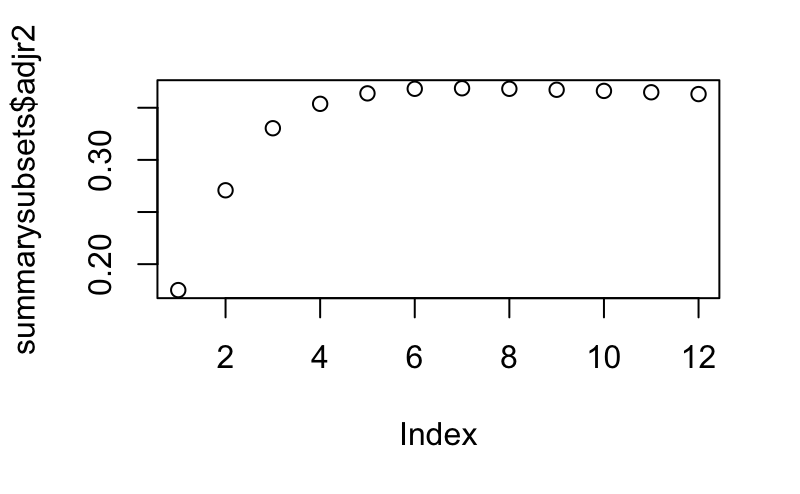

```r
plot(summarysubsets$adjr2)
```

```r
which.min(summarysubsets$cp)
```

```
[1] 6
```

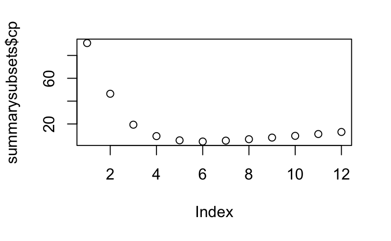

```r
plot(summarysubsets$cp)
```

```r
which.min(summarysubsets$bic)
```

```
[1] 5
```

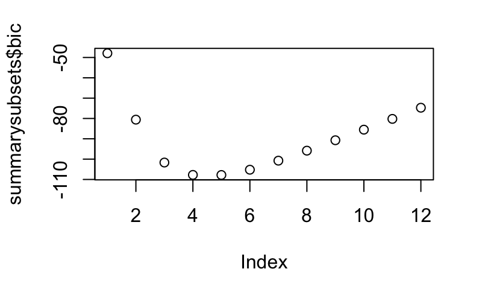

```r
plot(summarysubsets$bic)
```

We apply backward stepwise regression on to this model.

The best model is thalachh ~ age + trtbps + chol + exng + slp + output.

```r
reducedmodel = step(model,direction='backward')
```

```
Start:  AIC=3869.13
thalachh ~ age + sex + trtbps + chol + fbs + restecg + exng +
    oldpeak + slp + caa + thall + output

          Df Sum of Sq       RSS    AIC
- caa      1     78276  97771146 3867.4
- restecg  1    125798  97818668 3867.5
- fbs      1    193244  97886114 3867.7
- oldpeak  1    207592  97900463 3867.8
- sex      1    209901  97902772 3867.8
- thall    1    375050  98067920 3868.3
<none>                  97692871 3869.1
- chol     1    913809  98606680 3870.0
- trtbps   1   1687378  99380249 3872.3
- output   1   3769789 101462659 3878.6
- slp      1   3957736 101650606 3879.2
- exng     1   6441844 104134714 3886.5
- age      1  15468791 113161662 3911.7

Step:  AIC=3867.38
thalachh ~ age + sex + trtbps + chol + fbs + restecg + exng +
    oldpeak + slp + thall + output

          Df Sum of Sq       RSS    AIC
- restecg  1    125422  97896568 3865.8
- fbs      1    165584  97936731 3865.9
- sex      1    202616  97973763 3866.0
- oldpeak  1    238735  98009882 3866.1
- thall    1    369122  98140268 3866.5
<none>                  97771146 3867.4
- chol     1    912305  98683451 3868.2
- trtbps   1   1710748  99481895 3870.6
- slp      1   3880645 101651791 3877.2
- output   1   4508900 102280046 3879.0
- exng     1   6374358 104145504 3884.5
- age      1  16539209 114310355 3912.7

Step:  AIC=3865.76
thalachh ~ age + sex + trtbps + chol + fbs + exng + oldpeak +
    slp + thall + output
```

[output cut: 54 more lines]

```
- exng    1   6464059 105078978 3879.2
- slp     1   6544219 105159137 3879.4
- age     1  17263632 115878551 3908.9

Step:  AIC=3861.1
thalachh ~ age + trtbps + chol + exng + slp + output

         Df Sum of Sq       RSS    AIC
<none>                 98979429 3861.1
- chol    1    943374  99922803 3862.0
- trtbps  1   1844478 100823907 3864.7
- output  1   4471080 103450509 3872.5
- exng    1   6289274 105268703 3877.8
- slp     1   6611063 105590492 3878.7
- age     1  17402316 116381745 3908.2
```

We apply forward stepwise regression algorithm. The best model is thalachh ~ output + age + slp + exng + trtbps + chol.

```r
nullmodel = lm(thalachh~1)
forwardmodel = step(nullmodel,scope = ~age+sex+trtbps+chol+fbs+restecg+exng+oldpeak+slp+caa+thall+output,direction = 'forward')
```

```
Start:  AIC=3999.22
thalachh ~ 1

          Df Sum of Sq       RSS    AIC
+ output   1  29186250 133263834 3941.2
+ age      1  27163862 135286222 3945.8
+ slp      1  24551324 137898759 3951.6
+ exng     1  23908489 138541595 3953.0
+ oldpeak  1  19961364 142488720 3961.5
+ caa      1   7659660 154790424 3986.6
+ thall    1   1648281 160801803 3998.1
<none>                 162450084 3999.2
+ restecg  1    374807 162075277 4000.5
+ trtbps   1    363806 162086278 4000.5
+ sex      1    227624 162222460 4000.8
+ chol     1     41101 162408983 4001.1
+ fbs      1     16989 162433095 4001.2

Step:  AIC=3941.21
thalachh ~ output

          Df Sum of Sq       RSS    AIC
+ age      1  16805995 116457839 3902.4
+ slp      1  10819977 122443858 3917.6
+ exng     1   7910243 125353591 3924.7
+ oldpeak  1   5627889 127635945 3930.1
+ sex      1   1175728 132088106 3940.5
<none>                 133263834 3941.2
+ caa      1    501155 132762679 3942.1
+ thall    1    374671 132889163 3942.4
+ chol     1     66929 133196905 3943.1
+ trtbps   1     33028 133230806 3943.1
+ restecg  1     17002 133246832 3943.2
+ fbs      1       449 133263385 3943.2

Step:  AIC=3902.37
thalachh ~ output + age

          Df Sum of Sq       RSS    AIC
+ slp      1   8388702 108069137 3881.7
```

[output cut: 49 more lines]

```
+ fbs      1    201073 99721730 3863.4
+ sex      1    137693 99785111 3863.6
+ caa      1     57621 99865182 3863.8

Step:  AIC=3861.1
thalachh ~ output + age + slp + exng + trtbps + chol

          Df Sum of Sq      RSS    AIC
<none>                 98979429 3861.1
+ thall    1    364511 98614918 3862.0
+ sex      1    341011 98638418 3862.1
+ fbs      1    220633 98758796 3862.4
+ oldpeak  1    218010 98761419 3862.4
+ restecg  1    166893 98812536 3862.6
+ caa      1     56009 98923420 3862.9
```

We apply bidirectional stepwise regression to select the best model which is thalachh ~ output + age + slp + exng + trtbps + chol.

```r
nullmodel = lm(thalachh~1)
bothmodel = step(nullmodel,scope = ~age+sex+trtbps+chol+fbs+restecg+exng+oldpeak+slp+caa+thall+output,direction = 'both')
```

```
Start:  AIC=3999.22
thalachh ~ 1

          Df Sum of Sq       RSS    AIC
+ output   1  29186250 133263834 3941.2
+ age      1  27163862 135286222 3945.8
+ slp      1  24551324 137898759 3951.6
+ exng     1  23908489 138541595 3953.0
+ oldpeak  1  19961364 142488720 3961.5
+ caa      1   7659660 154790424 3986.6
+ thall    1   1648281 160801803 3998.1
<none>                 162450084 3999.2
+ restecg  1    374807 162075277 4000.5
+ trtbps   1    363806 162086278 4000.5
+ sex      1    227624 162222460 4000.8
+ chol     1     41101 162408983 4001.1
+ fbs      1     16989 162433095 4001.2

Step:  AIC=3941.21
thalachh ~ output

          Df Sum of Sq       RSS    AIC
+ age      1  16805995 116457839 3902.4
+ slp      1  10819977 122443858 3917.6
+ exng     1   7910243 125353591 3924.7
+ oldpeak  1   5627889 127635945 3930.1
+ sex      1   1175728 132088106 3940.5
<none>                 133263834 3941.2
+ caa      1    501155 132762679 3942.1
+ thall    1    374671 132889163 3942.4
+ chol     1     66929 133196905 3943.1
+ trtbps   1     33028 133230806 3943.1
+ restecg  1     17002 133246832 3943.2
+ fbs      1       449 133263385 3943.2
- output   1  29186250 162450084 3999.2

Step:  AIC=3902.37
thalachh ~ output + age

          Df Sum of Sq       RSS    AIC
```

[output cut: 70 more lines]

```

          Df Sum of Sq       RSS    AIC
<none>                  98979429 3861.1
- chol     1    943374  99922803 3862.0
+ thall    1    364511  98614918 3862.0
+ sex      1    341011  98638418 3862.1
+ fbs      1    220633  98758796 3862.4
+ oldpeak  1    218010  98761419 3862.4
+ restecg  1    166893  98812536 3862.6
+ caa      1     56009  98923420 3862.9
- trtbps   1   1844478 100823907 3864.7
- output   1   4471080 103450509 3872.5
- exng     1   6289274 105268703 3877.8
- slp      1   6611063 105590492 3878.7
- age      1  17402316 116381745 3908.2
```

So we select all the models that were selected by stepwise and subset regression and create new models.

```r
newmodel = lm(thalachh ~ age + trtbps + chol + exng + slp + output)
newmodel1 = lm(thalachh ~ output + age + slp + exng + trtbps + chol)
newmodel2 = lm(thalachh ~ age + trtbps + chol + exng + slp + thall + output)
newmodel5 = lm(thalachh ~ age + trtbps + exng + slp + output)
```

Main points from the summary of the thalachh ~ age + trtbps + chol + exng + slp + output model.

1.(10% level) All the variables are statistically significant

2.Trtbps and chol are not statistically significant based on anova table.

2.Overall regression is significant.

3.The sample standard deviation 578.3.

4.Multiple R squared is 0.3907.

5.Adjusted R squared is 0.3784.

Regarding the unusual values and influential observations of the model.

1. Number of high leverage values are 8.
2. Number of very high leverage values are 2.
3. There are no influential observations in the data.

Regarding regression assumptions:

1.Linearity assumption is valid based on residual plots

2.Constant variance assumption is valid based on residual plots

3.Normality assumption is not valid based on qqplot and shapiro-wilk test.

4.There is no perfect multicollinearity based on variance inflation factor.

```r
summary(newmodel)
```

```
Call:
lm(formula = thalachh ~ age + trtbps + chol + exng + slp + output)

Residuals:
     Min       1Q   Median       3Q      Max
-1705.03  -358.18    33.09   375.05  1449.70

Coefficients:
             Estimate Std. Error t value Pr(>|t|)
(Intercept) 3364.5248   339.5159   9.910  < 2e-16 ***
age          -28.6468     3.9710  -7.214 4.57e-12 ***
trtbps         4.6760     1.9910   2.349 0.019502 *
chol           1.1094     0.6605   1.680 0.094083 .
exng        -344.5554    79.4485  -4.337 1.98e-05 ***
slp          260.0604    58.4878   4.446 1.24e-05 ***
output       286.4314    78.3323   3.657 0.000302 ***
---
Signif. codes:
0 ‘***’ 0.001 ‘**’ 0.01 ‘*’ 0.05 ‘.’ 0.1 ‘ ’ 1

Residual standard error: 578.3 on 296 degrees of freedom
Multiple R-squared:  0.3907,    Adjusted R-squared:  0.3784
F-statistic: 31.64 on 6 and 296 DF,  p-value: < 2.2e-16
```

```r
anova(newmodel)
```

```
Analysis of Variance Table

Response: thalachh
           Df   Sum Sq  Mean Sq F value    Pr(>F)
age         1 27163862 27163862 81.2341 < 2.2e-16 ***
trtbps      1   788797   788797  2.3589 0.1256372
chol        1   764519   764519  2.2863 0.1315869
exng        1 20172152 20172152 60.3252 1.326e-13 ***
slp         1 10110245 10110245 30.2349 8.277e-08 ***
output      1  4471080  4471080 13.3709 0.0003024 ***
Residuals 296 98979429   334390
---
Signif. codes:
0 ‘***’ 0.001 ‘**’ 0.01 ‘*’ 0.05 ‘.’ 0.1 ‘ ’ 1
```

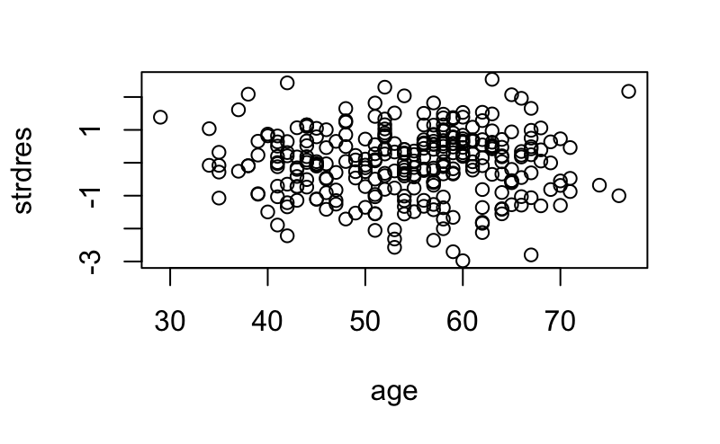

```r
strdres = rstandard(newmodel)
fit = fitted(newmodel)
plot(age,strdres)
```

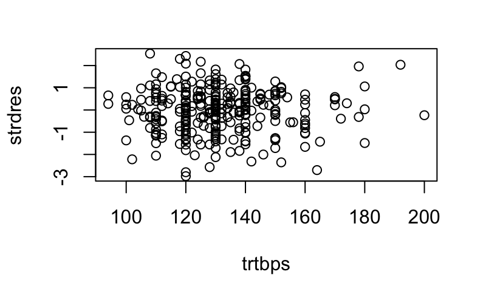

```r
plot(trtbps,strdres)
```

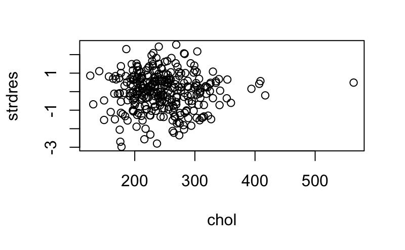

```r
plot(chol,strdres)
```

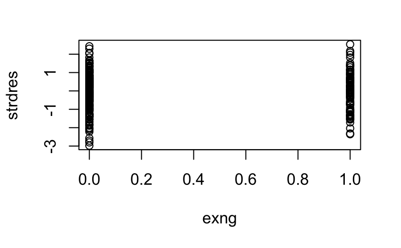

```r
plot(exng,strdres)
```

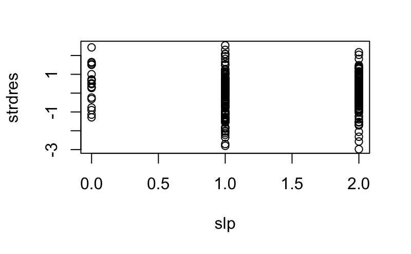

```r
plot(slp,strdres)
```

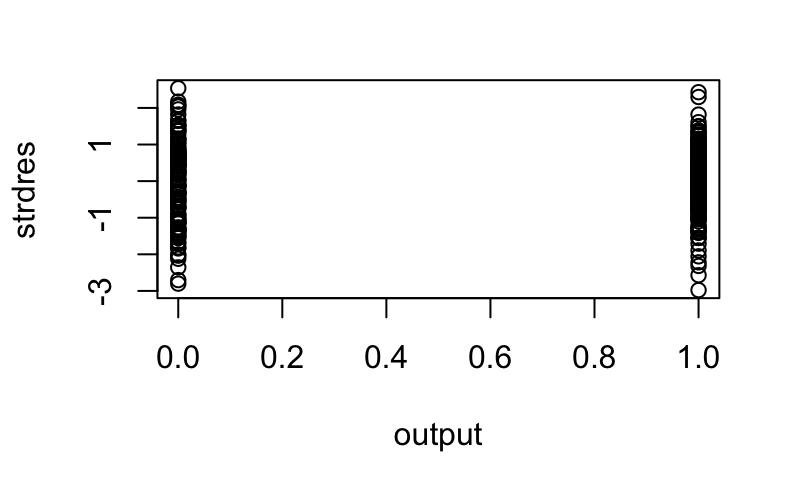

```r
plot(output,strdres)
```

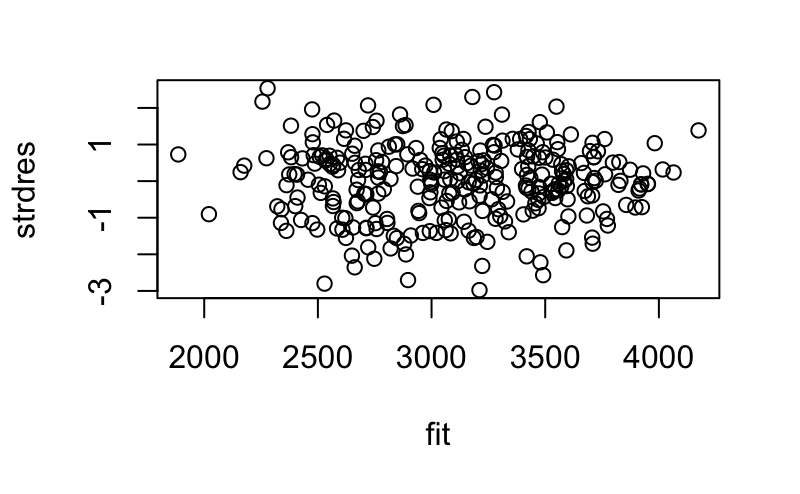

```r
plot(fit,strdres)
```

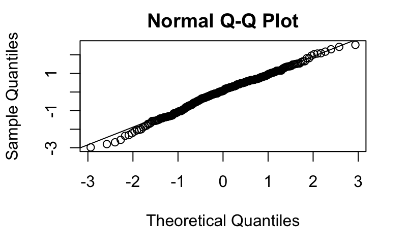

```r
qqnorm(strdres)
qqline(strdres)
```

```r
shapiro.test(strdres)
```

```
    Shapiro-Wilk normality test

data:  strdres
W = 0.9917, p-value = 0.08699
```

```r
p = length(coef(newmodel))
n = length(strdres)
leverage = hatvalues(newmodel)
na = 0
nb = 0
for (i in leverage){
  if (i>(2*p)/n & i <= (3*p)/n){
    print('high leverage')
    print(i)
    na = na + 1
  }else if (i > (3*p)/n){
    print('Very high leverage')
    print(i)
    nb = nb + 1
  }else{
    next
  }
}
```

```
[1] "high leverage"
[1] 0.04848344
[1] "high leverage"
[1] 0.04788243
[1] "high leverage"
[1] 0.05040339
[1] "Very high leverage"
[1] 0.1513245
[1] "high leverage"
[1] 0.05576519
[1] "high leverage"
[1] 0.05786097
[1] "high leverage"
[1] 0.04867294
[1] "high leverage"
[1] 0.04699768
[1] "Very high leverage"
[1] 0.0726409
[1] "high leverage"
[1] 0.06175673
```

```r
paste("Number of high leverage values are", na, sep = " ")
```

```
[1] "Number of high leverage values are 8"
```

```r
paste("Number of very high leverage values are", nb, sep = " ")
```

```
[1] "Number of very high leverage values are 2"
```

```r
cooks = cooks.distance(newmodel)
if (max(cooks) > qf(0.5,p-1,n-p)){
  print('There are influential observations in the data')
}else{
  print('No influential observations')
}
```

```
[1] "No influential observations"
```

```r
print("Variance inflation factor for each independent variable")
```

```
[1] "Variance inflation factor for each independent variable"
```

```r
vif(newmodel)
```

```
     age   trtbps     chol     exng      slp   output
1.174694 1.101173 1.058463 1.258173 1.173179 1.378952
```

Main points from the summary of the thalachh ~ output + age + slp + exng + trtbps + chol model

1.(10% level) All the variables are statisitcally significant

2.(10% level) All the variables are statistically significant based on anova table.

3.Overall regression is significant.

4.The sample standard deviation 578.3.

5.Multiple R squared is 0.3907.

6.Adjusted R squared is 0.3784.

Regarding the unusual values and influential observations of the model.

1. Number of high leverage values are 8.
2. Number of very high leverage values are 2.
3. There are no influential observations in the data.

Regarding regression assumptions:

1.Linearity assumption is valid based on residual plots

2.Constant variance assumption is valid based on residual plots

3.Normality assumption is not valid based on qqplot and shapiro-wilk test.(Although there is weak evidence against the hypthosis of normality)

4.There is no perfect multicollinearity in this model based variance inflation factor.

```r
#thalachh ~ output + age + slp + exng + trtbps + chol
summary(newmodel1)
```

```
Call:
lm(formula = thalachh ~ output + age + slp + exng + trtbps +
    chol)

Residuals:
     Min       1Q   Median       3Q      Max
-1705.03  -358.18    33.09   375.05  1449.70

Coefficients:
             Estimate Std. Error t value Pr(>|t|)
(Intercept) 3364.5248   339.5159   9.910  < 2e-16 ***
output       286.4314    78.3323   3.657 0.000302 ***
age          -28.6468     3.9710  -7.214 4.57e-12 ***
slp          260.0604    58.4878   4.446 1.24e-05 ***
exng        -344.5554    79.4485  -4.337 1.98e-05 ***
trtbps         4.6760     1.9910   2.349 0.019502 *
chol           1.1094     0.6605   1.680 0.094083 .
---
Signif. codes:
0 ‘***’ 0.001 ‘**’ 0.01 ‘*’ 0.05 ‘.’ 0.1 ‘ ’ 1

Residual standard error: 578.3 on 296 degrees of freedom
Multiple R-squared:  0.3907,    Adjusted R-squared:  0.3784
F-statistic: 31.64 on 6 and 296 DF,  p-value: < 2.2e-16
```

```r
anova(newmodel1)
```

```
Analysis of Variance Table

Response: thalachh
           Df   Sum Sq  Mean Sq F value    Pr(>F)
output      1 29186250 29186250 87.2821 < 2.2e-16 ***
age         1 16805995 16805995 50.2587 9.924e-12 ***
slp         1  8388702  8388702 25.0866 9.437e-07 ***
exng        1  6110411  6110411 18.2733 2.584e-05 ***
trtbps      1  2035923  2035923  6.0885   0.01417 *
chol        1   943374   943374  2.8212   0.09408 .
Residuals 296 98979429   334390
---
Signif. codes:
0 ‘***’ 0.001 ‘**’ 0.01 ‘*’ 0.05 ‘.’ 0.1 ‘ ’ 1
```

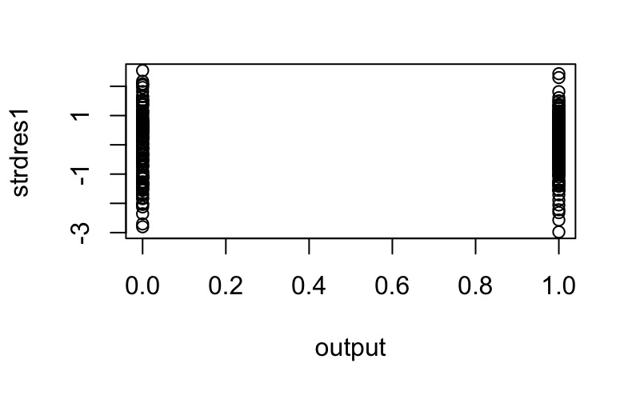

```r
strdres1 = rstandard(newmodel1)
fit1 = fitted(newmodel1)
plot(output,strdres1)
```

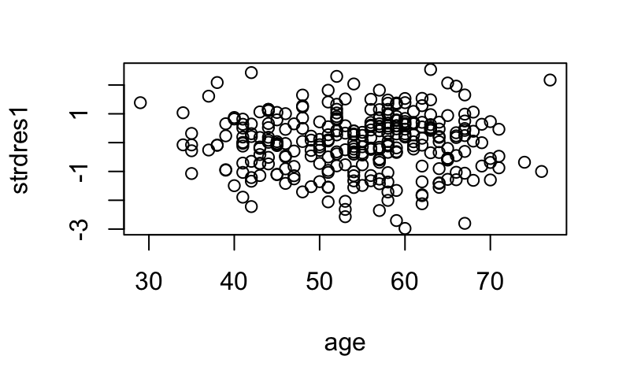

```r
plot(age,strdres1)
```

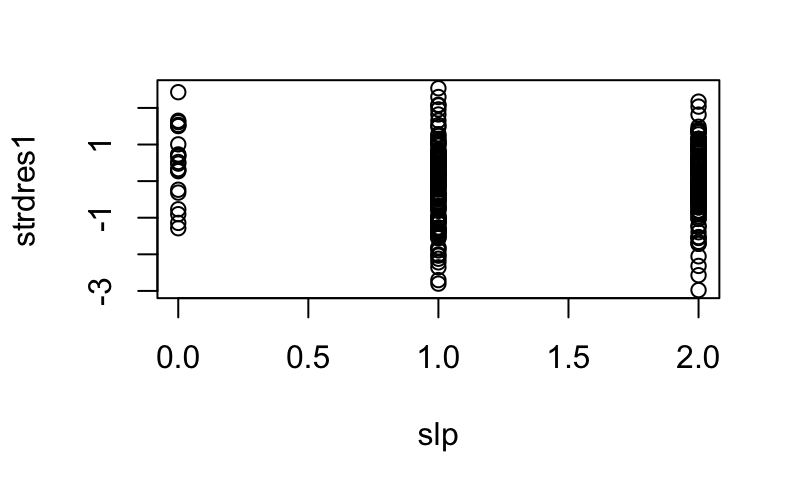

```r
plot(slp,strdres1)
```

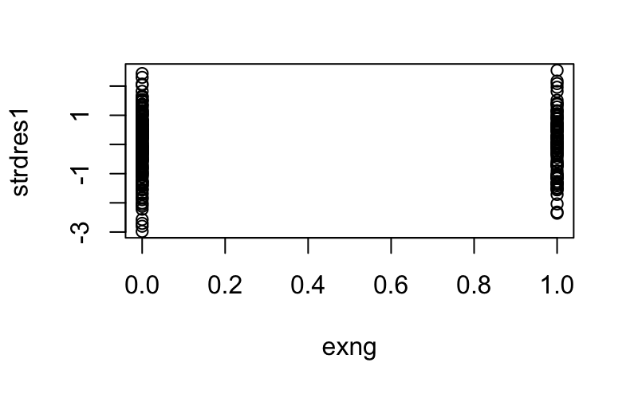

```r
plot(exng,strdres1)
```

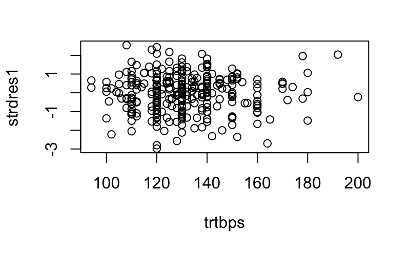

```r
plot(trtbps,strdres1)
```

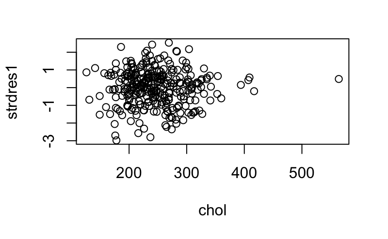

```r
plot(chol,strdres1)
```

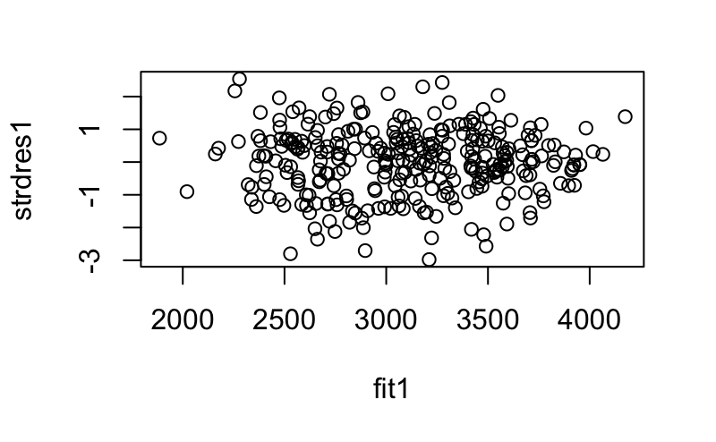

```r
plot(fit1,strdres1)
```

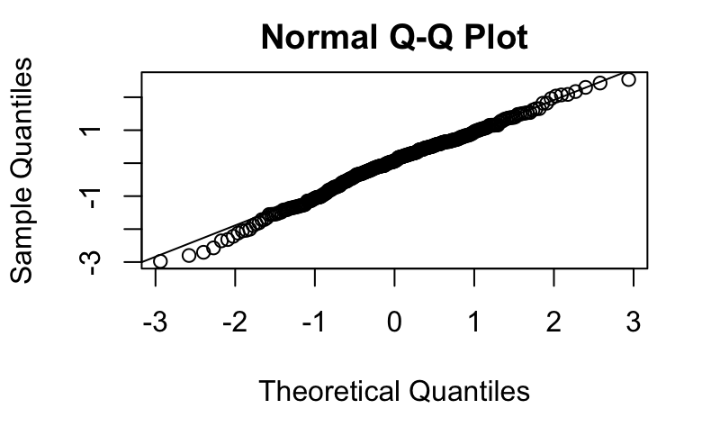

```r
qqnorm(strdres1)
qqline(strdres1)
```

```r
shapiro.test(strdres1)
```

```
    Shapiro-Wilk normality test

data:  strdres1
W = 0.9917, p-value = 0.08699
```

```r
p = length(coef(newmodel1))
n = length(strdres1)
leverage = hatvalues(newmodel1)
na = 0
nb = 0
for (i in leverage){
  if (i>(2*p)/n & i <= (3*p)/n){
    print('high leverage')
    print(i)
    na = na + 1
  }else if (i > (3*p)/n){
    print('Very high leverage')
    print(i)
    nb = nb + 1
  }else{
    next
  }
}
```

```
[1] "high leverage"
[1] 0.04848344
[1] "high leverage"
[1] 0.04788243
[1] "high leverage"
[1] 0.05040339
[1] "Very high leverage"
[1] 0.1513245
[1] "high leverage"
[1] 0.05576519
[1] "high leverage"
[1] 0.05786097
[1] "high leverage"
[1] 0.04867294
[1] "high leverage"
[1] 0.04699768
[1] "Very high leverage"
[1] 0.0726409
[1] "high leverage"
[1] 0.06175673
```

```r
paste("Number of high leverage values are", na, sep = " ")
```

```
[1] "Number of high leverage values are 8"
```

```r
paste("Number of very high leverage values are", nb, sep = " ")
```

```
[1] "Number of very high leverage values are 2"
```

```r
cooks = cooks.distance(newmodel1)
if (max(cooks) > qf(0.5,p-1,n-p)){
  print('There are influential in the data')
}else{
  print('No influential observations')
}
```

```
[1] "No influential observations"
```

```r
print("Variance inflation factor for each independent variable")
```

```
[1] "Variance inflation factor for each independent variable"
```

```r
vif(newmodel1)
```

```
  output      age      slp     exng   trtbps     chol
1.378952 1.174694 1.173179 1.258173 1.101173 1.058463
```

Main points from the summary of the thalachh ~ age + trtbps + chol + exng + slp + thall + output.

1.The variables that are not statistically significant are chol and thall.

3.Overall regression is significant.

4.The sample standard deviation 578.2.

5.Multiple R squared is 0.393.

6.Adjusted R squared is 0.3785.

Regarding the unusual values and influential observations of the model.

1. Number of high leverage values are 9.
2. Number of very high leverage values are 2.
3. There are no influential observations in the data.

Regarding regression assumptions:

1.Linearity assumption is valid based on residual plots

2.Constant variance assumption is valid based on residual plots

4.There is no perfect multicollinearity in this model based variance inflation factor.

```r
#thalachh ~ age + trtbps + chol + exng + slp + thall + output
summary(newmodel2)
```

```
Call:
lm(formula = thalachh ~ age + trtbps + chol + exng + slp + thall +
    output)

Residuals:
     Min       1Q   Median       3Q      Max
-1702.22  -364.93    42.74   380.52  1484.55

Coefficients:
             Estimate Std. Error t value Pr(>|t|)
(Intercept) 3224.8389   364.8701   8.838  < 2e-16 ***
age          -28.5416     3.9717  -7.186 5.47e-12 ***
trtbps         4.6500     1.9908   2.336 0.020176 *
chol           1.0584     0.6622   1.598 0.111036
exng        -350.0859    79.6127  -4.397 1.53e-05 ***
slp          258.7976    58.4914   4.425 1.36e-05 ***
thall         60.7615    58.1880   1.044 0.297235
output       310.2014    81.5613   3.803 0.000174 ***
---
Signif. codes:
0 ‘***’ 0.001 ‘**’ 0.01 ‘*’ 0.05 ‘.’ 0.1 ‘ ’ 1

Residual standard error: 578.2 on 295 degrees of freedom
Multiple R-squared:  0.393, Adjusted R-squared:  0.3785
F-statistic: 27.28 on 7 and 295 DF,  p-value: < 2.2e-16
```

```r
anova(newmodel2)
```

```
Analysis of Variance Table

Response: thalachh
           Df   Sum Sq  Mean Sq F value    Pr(>F)
age         1 27163862 27163862 81.2589 < 2.2e-16 ***
trtbps      1   788797   788797  2.3596 0.1255833
chol        1   764519   764519  2.2870 0.1315318
exng        1 20172152 20172152 60.3437 1.327e-13 ***
slp         1 10110245 10110245 30.2441 8.261e-08 ***
thall       1      108      108  0.0003 0.9856829
output      1  4835483  4835483 14.4650 0.0001736 ***
Residuals 295 98614918   334288
---
Signif. codes:
0 ‘***’ 0.001 ‘**’ 0.01 ‘*’ 0.05 ‘.’ 0.1 ‘ ’ 1
```

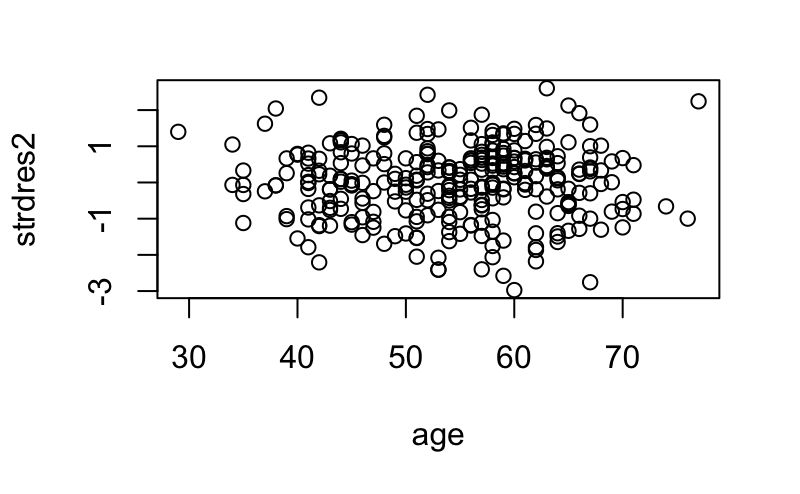

```r
strdres2 = rstandard(newmodel2)
fit2 = fitted(newmodel2)
plot(age,strdres2)
```

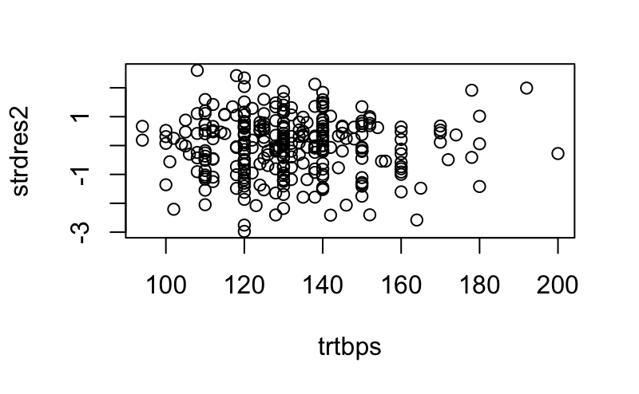

```r
plot(trtbps,strdres2)
```

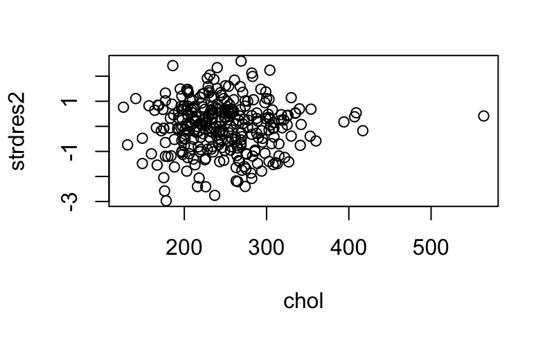

```r
plot(chol,strdres2)
```

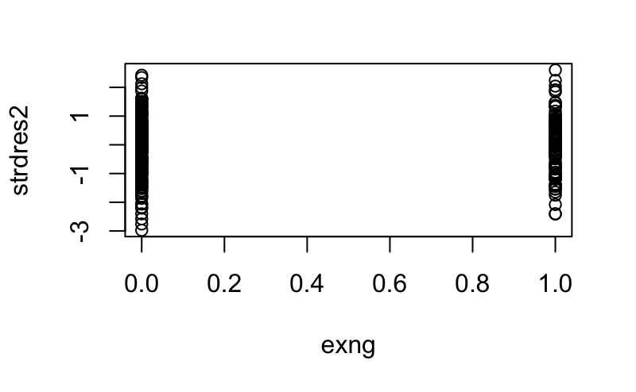

```r
plot(exng,strdres2)
```

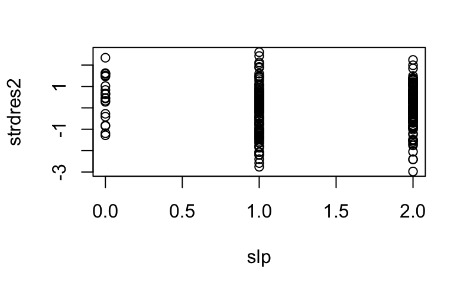

```r
plot(slp,strdres2)
```

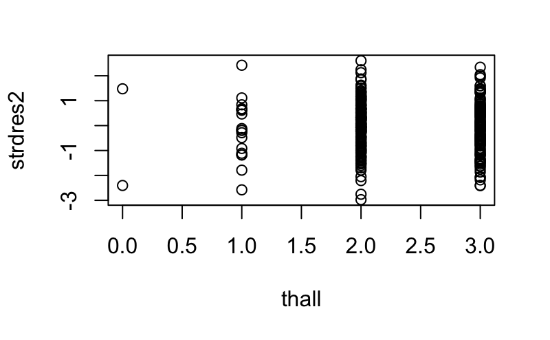

```r
plot(thall,strdres2)
```

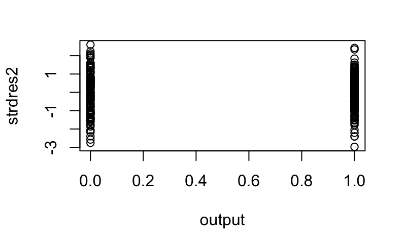

```r
plot(output,strdres2)
```

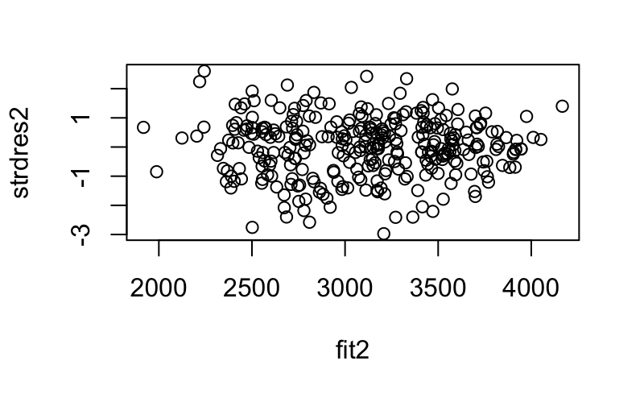

```r
plot(fit2,strdres2)
```

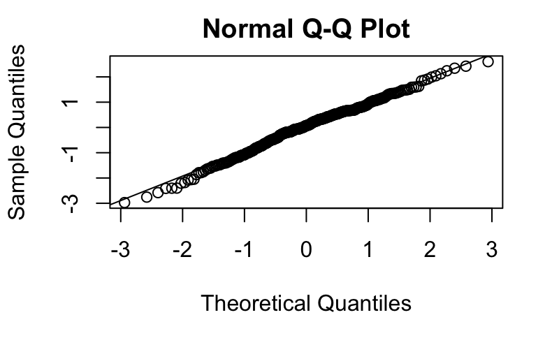

```r
qqnorm(strdres2)
qqline(strdres2)
```

```r
shapiro.test(strdres2)
```

```
    Shapiro-Wilk normality test

data:  strdres2
W = 0.99233, p-value = 0.1199
```

```r
p = length(coef(newmodel2))
n = length(strdres2)
leverage = hatvalues(newmodel2)
na = 0
nb = 0
for (i in leverage){
  if (i>(2*p)/n & i <= (3*p)/n){
    print('high leverage')
    print(i)
    na = na + 1
  }else if (i > (3*p)/n){
    print('Very high leverage')
    print(i)
    nb = nb + 1
  }else{
    next
  }
}
```

```
[1] "high leverage"
[1] 0.05335567
[1] "Very high leverage"
[1] 0.1558051
[1] "high leverage"
[1] 0.06381897
[1] "high leverage"
[1] 0.05865056
[1] "high leverage"
[1] 0.05337074
[1] "high leverage"
[1] 0.07410179
[1] "high leverage"
[1] 0.06365919
[1] "high leverage"
[1] 0.05710899
[1] "Very high leverage"
[1] 0.08024596
[1] "high leverage"
[1] 0.06629957
[1] "high leverage"
[1] 0.06076437
```

```r
paste("Number of high leverage values are", na, sep = " ")
```

```
[1] "Number of high leverage values are 9"
```

```r
paste("Number of very high leverage values are", nb, sep = " ")
```

```
[1] "Number of very high leverage values are 2"
```

```r
cooks = cooks.distance(newmodel2)
if (max(cooks) > qf(0.5,p-1,n-p)){
  print('There are influential obsevations in the data')
}else{
  print('No influential observations')
}
```

```
[1] "No influential observations"
```

```r
print("Variance inflation factor for each independent variable")
```

```
[1] "Variance inflation factor for each independent variable"
```

```r
vif(newmodel2)
```

```
     age   trtbps     chol     exng      slp    thall
1.175450 1.101345 1.064246 1.263766 1.173681 1.146697
  output
1.495437
```

Main points from the summary of the thalachh ~ age + trtbps + exng + slp + output.

3.Overall regression is significant.